# Lab 2

Author

Antonio Gutierrez

# Lab 2: Avocado Prices

## 0. Importing the data and declaring package dependencies.

```python
import numpy as np
import pandas as pd
from plotnine import *
```

```python
data = pd.read_csv('/content/avocado-updated-2020.csv')
```

## 1. Briefly describe the data set. What information does it contain?

This file contains historical data on avocado prices & volume by region & year along with the type of avocado and bag type.

```python
data
```

|  | date | average_price | total_volume | 4046 | 4225 | 4770 | total_bags | small_bags | large_bags | xlarge_bags | type | year | geography |
| --- | --- | --- | --- | --- | --- | --- | --- | --- | --- | --- | --- | --- | --- |
| 0 | 2015-01-04 | 1.22 | 40873.28 | 2819.50 | 28287.42 | 49.90 | 9716.46 | 9186.93 | 529.53 | 0.00 | conventional | 2015 | Albany |
| 1 | 2015-01-04 | 1.79 | 1373.95 | 57.42 | 153.88 | 0.00 | 1162.65 | 1162.65 | 0.00 | 0.00 | organic | 2015 | Albany |
| 2 | 2015-01-04 | 1.00 | 435021.49 | 364302.39 | 23821.16 | 82.15 | 46815.79 | 16707.15 | 30108.64 | 0.00 | conventional | 2015 | Atlanta |
| 3 | 2015-01-04 | 1.76 | 3846.69 | 1500.15 | 938.35 | 0.00 | 1408.19 | 1071.35 | 336.84 | 0.00 | organic | 2015 | Atlanta |
| 4 | 2015-01-04 | 1.08 | 788025.06 | 53987.31 | 552906.04 | 39995.03 | 141136.68 | 137146.07 | 3990.61 | 0.00 | conventional | 2015 | Baltimore/Washington |
| ... | ... | ... | ... | ... | ... | ... | ... | ... | ... | ... | ... | ... | ... |
| 33040 | 2020-11-29 | 1.47 | 1583056.27 | 67544.48 | 97996.46 | 2617.17 | 1414878.10 | 906711.52 | 480191.83 | 27974.75 | organic | 2020 | Total U.S. |
| 33041 | 2020-11-29 | 0.91 | 5811114.22 | 1352877.53 | 589061.83 | 19741.90 | 3790665.29 | 2197611.02 | 1531530.14 | 61524.13 | conventional | 2020 | West |
| 33042 | 2020-11-29 | 1.48 | 289961.27 | 13273.75 | 19341.09 | 636.51 | 256709.92 | 122606.21 | 134103.71 | 0.00 | organic | 2020 | West |
| 33043 | 2020-11-29 | 0.67 | 822818.75 | 234688.01 | 80205.15 | 10543.63 | 497381.96 | 285764.11 | 210808.02 | 809.83 | conventional | 2020 | West Tex/New Mexico |
| 33044 | 2020-11-29 | 1.35 | 24106.58 | 1236.96 | 617.80 | 1564.98 | 20686.84 | 17824.52 | 2862.32 | 0.00 | organic | 2020 | West Tex/New Mexico |

33045 rows × 13 columns

## 2. Clean the data in any way you see fit.

Upon inital review, there does not appear to be any glaring issues with the data set. Additional changes may be made as needed and noted accordingly. It appears changes will need to be made with some of the columns.

## 3. Which major geographical region sold the most total organic, small Hass avocados in 2017?

In order to accomplish this, we first need to create a new column type that allows us to differentiate the geographies.

```python
avocado_clean = data

# Classifying the geography

states = ['California', 'South Carolina']
regions = ['Midsouth', 'Northeast', 'Plains', 'South Central', 'Southeast', 'West', 'Great Lakes']

def classify_geography(geo): # ChatGPT assisted with template to incorportae if or else for multiple options.
    if geo in states:
        return "state"
    elif geo in regions:
        return "region"
    elif geo == "Total U.S.":
        return "Total U.S."
    else:
        return "metro area"

avocado_clean['geography type'] = avocado_clean['geography'].apply(classify_geography)

avocado_clean
```

|  | date | average_price | total_volume | 4046 | 4225 | 4770 | total_bags | small_bags | large_bags | xlarge_bags | type | year | geography | geography type |
| --- | --- | --- | --- | --- | --- | --- | --- | --- | --- | --- | --- | --- | --- | --- |
| 0 | 2015-01-04 | 1.22 | 40873.28 | 2819.50 | 28287.42 | 49.90 | 9716.46 | 9186.93 | 529.53 | 0.00 | conventional | 2015 | Albany | metro area |
| 1 | 2015-01-04 | 1.79 | 1373.95 | 57.42 | 153.88 | 0.00 | 1162.65 | 1162.65 | 0.00 | 0.00 | organic | 2015 | Albany | metro area |
| 2 | 2015-01-04 | 1.00 | 435021.49 | 364302.39 | 23821.16 | 82.15 | 46815.79 | 16707.15 | 30108.64 | 0.00 | conventional | 2015 | Atlanta | metro area |
| 3 | 2015-01-04 | 1.76 | 3846.69 | 1500.15 | 938.35 | 0.00 | 1408.19 | 1071.35 | 336.84 | 0.00 | organic | 2015 | Atlanta | metro area |
| 4 | 2015-01-04 | 1.08 | 788025.06 | 53987.31 | 552906.04 | 39995.03 | 141136.68 | 137146.07 | 3990.61 | 0.00 | conventional | 2015 | Baltimore/Washington | metro area |
| ... | ... | ... | ... | ... | ... | ... | ... | ... | ... | ... | ... | ... | ... | ... |
| 33040 | 2020-11-29 | 1.47 | 1583056.27 | 67544.48 | 97996.46 | 2617.17 | 1414878.10 | 906711.52 | 480191.83 | 27974.75 | organic | 2020 | Total U.S. | Total U.S. |
| 33041 | 2020-11-29 | 0.91 | 5811114.22 | 1352877.53 | 589061.83 | 19741.90 | 3790665.29 | 2197611.02 | 1531530.14 | 61524.13 | conventional | 2020 | West | region |
| 33042 | 2020-11-29 | 1.48 | 289961.27 | 13273.75 | 19341.09 | 636.51 | 256709.92 | 122606.21 | 134103.71 | 0.00 | organic | 2020 | West | region |
| 33043 | 2020-11-29 | 0.67 | 822818.75 | 234688.01 | 80205.15 | 10543.63 | 497381.96 | 285764.11 | 210808.02 | 809.83 | conventional | 2020 | West Tex/New Mexico | metro area |
| 33044 | 2020-11-29 | 1.35 | 24106.58 | 1236.96 | 617.80 | 1564.98 | 20686.84 | 17824.52 | 2862.32 | 0.00 | organic | 2020 | West Tex/New Mexico | metro area |

33045 rows × 14 columns

```python
# Filtering data to meet requirements.
avocado_clean = avocado_clean[(avocado_clean['year'] == 2017) & (avocado_clean['type'] == 'organic') & (avocado_clean['geography type'] == 'region')]

avocado_clean
```

|  | date | average_price | total_volume | 4046 | 4225 | 4770 | total_bags | small_bags | large_bags | xlarge_bags | type | year | geography | geography type |
| --- | --- | --- | --- | --- | --- | --- | --- | --- | --- | --- | --- | --- | --- | --- |
| 11262 | 2017-01-01 | 1.44 | 104153.91 | 4104.86 | 69800.29 | 0.00 | 30248.76 | 23593.03 | 6655.73 | 0.00 | organic | 2017 | Great Lakes | region |
| 11282 | 2017-01-01 | 1.72 | 72287.79 | 3353.64 | 36090.72 | 1813.60 | 31029.83 | 29203.33 | 1826.50 | 0.00 | organic | 2017 | Midsouth | region |
| 11290 | 2017-01-01 | 2.00 | 115256.09 | 9132.13 | 36276.39 | 923.53 | 68924.04 | 65447.53 | 3476.51 | 0.00 | organic | 2017 | Northeast | region |
| 11302 | 2017-01-01 | 1.62 | 47042.21 | 4547.17 | 15245.73 | 1366.36 | 25882.95 | 17253.74 | 8629.21 | 0.00 | organic | 2017 | Plains | region |
| 11322 | 2017-01-01 | 1.23 | 66616.54 | 22474.95 | 4797.17 | 17.37 | 39327.05 | 37358.81 | 1968.24 | 0.00 | organic | 2017 | South Central | region |
| ... | ... | ... | ... | ... | ... | ... | ... | ... | ... | ... | ... | ... | ... | ... |
| 16904 | 2017-12-31 | 1.66 | 229313.64 | 11281.04 | 33549.86 | 122.83 | 184359.91 | 170878.67 | 13481.24 | 0.00 | organic | 2017 | Northeast | region |
| 16916 | 2017-12-31 | 1.63 | 62228.22 | 3018.47 | 15029.08 | 38.91 | 44141.76 | 32311.88 | 11829.88 | 0.00 | organic | 2017 | Plains | region |
| 16936 | 2017-12-31 | 1.41 | 115959.77 | 25221.46 | 3103.46 | 0.00 | 87634.85 | 82290.07 | 5344.78 | 0.00 | organic | 2017 | South Central | region |
| 16938 | 2017-12-31 | 1.40 | 92000.75 | 1052.21 | 15703.49 | 169.38 | 75075.67 | 69576.29 | 5499.38 | 0.00 | organic | 2017 | Southeast | region |
| 16950 | 2017-12-31 | 1.48 | 229477.07 | 26883.07 | 53165.30 | 86.61 | 149342.09 | 66254.72 | 82977.60 | 109.77 | organic | 2017 | West | region |

371 rows × 14 columns

```python
# Now that the data is cleaned and filtered as needed, we only have the data that fits the requirements, and can now sort the data

avocado_clean[avocado_clean['geography'].isin(regions)].groupby('geography')['4046'].sum().sort_values(ascending=False)
```

```
geography
West             1870206.29
South Central    1717104.19
Northeast         925832.36
Southeast         285124.34
Great Lakes       202487.68
Midsouth          186395.50
Plains            168583.40
Name: 4046, dtype: float64
```

The West is the major geographical area that sold the most small Hass avocados in 2017.

## 4. Split the date variable into month, day, and year variables. In which month is the highest average volume of avocado sales?

```python
# First create the new columns so that we can sort the data

data['date'] = pd.to_datetime(data['date'])

data['month'] = data['date'].dt.month
data['day'] = data['date'].dt.day
data['year_column'] = data['date'].dt.year

avocado_clean = data
avocado_clean
```

|  | date | average_price | total_volume | 4046 | 4225 | 4770 | total_bags | small_bags | large_bags | xlarge_bags | type | year | geography | geography type | month | day | year_column |
| --- | --- | --- | --- | --- | --- | --- | --- | --- | --- | --- | --- | --- | --- | --- | --- | --- | --- |
| 0 | 2015-01-04 | 1.22 | 40873.28 | 2819.50 | 28287.42 | 49.90 | 9716.46 | 9186.93 | 529.53 | 0.00 | conventional | 2015 | Albany | metro area | 1 | 4 | 2015 |
| 1 | 2015-01-04 | 1.79 | 1373.95 | 57.42 | 153.88 | 0.00 | 1162.65 | 1162.65 | 0.00 | 0.00 | organic | 2015 | Albany | metro area | 1 | 4 | 2015 |
| 2 | 2015-01-04 | 1.00 | 435021.49 | 364302.39 | 23821.16 | 82.15 | 46815.79 | 16707.15 | 30108.64 | 0.00 | conventional | 2015 | Atlanta | metro area | 1 | 4 | 2015 |
| 3 | 2015-01-04 | 1.76 | 3846.69 | 1500.15 | 938.35 | 0.00 | 1408.19 | 1071.35 | 336.84 | 0.00 | organic | 2015 | Atlanta | metro area | 1 | 4 | 2015 |
| 4 | 2015-01-04 | 1.08 | 788025.06 | 53987.31 | 552906.04 | 39995.03 | 141136.68 | 137146.07 | 3990.61 | 0.00 | conventional | 2015 | Baltimore/Washington | metro area | 1 | 4 | 2015 |
| ... | ... | ... | ... | ... | ... | ... | ... | ... | ... | ... | ... | ... | ... | ... | ... | ... | ... |
| 33040 | 2020-11-29 | 1.47 | 1583056.27 | 67544.48 | 97996.46 | 2617.17 | 1414878.10 | 906711.52 | 480191.83 | 27974.75 | organic | 2020 | Total U.S. | Total U.S. | 11 | 29 | 2020 |
| 33041 | 2020-11-29 | 0.91 | 5811114.22 | 1352877.53 | 589061.83 | 19741.90 | 3790665.29 | 2197611.02 | 1531530.14 | 61524.13 | conventional | 2020 | West | region | 11 | 29 | 2020 |
| 33042 | 2020-11-29 | 1.48 | 289961.27 | 13273.75 | 19341.09 | 636.51 | 256709.92 | 122606.21 | 134103.71 | 0.00 | organic | 2020 | West | region | 11 | 29 | 2020 |
| 33043 | 2020-11-29 | 0.67 | 822818.75 | 234688.01 | 80205.15 | 10543.63 | 497381.96 | 285764.11 | 210808.02 | 809.83 | conventional | 2020 | West Tex/New Mexico | metro area | 11 | 29 | 2020 |
| 33044 | 2020-11-29 | 1.35 | 24106.58 | 1236.96 | 617.80 | 1564.98 | 20686.84 | 17824.52 | 2862.32 | 0.00 | organic | 2020 | West Tex/New Mexico | metro area | 11 | 29 | 2020 |

33045 rows × 17 columns

```python
avocado_clean.groupby('month')['total_volume'].mean().sort_values(ascending=False)
```

```
month
5     1.123632e+06
2     1.095374e+06
6     1.051247e+06
4     1.016582e+06
3     9.957150e+05
1     9.853122e+05
7     9.832681e+05
8     9.499249e+05
9     9.064773e+05
10    8.446863e+05
11    8.223470e+05
12    8.076695e+05
Name: total_volume, dtype: float64
```

The month with the highest average volume of avocado sales was the fifth month, May.

## 5. Which metro area geographical regions sold the most total avocados? Plot side-by-side box-plots of the total volume for only the five metro geographical regions with the highest averages for the total_volume variable.

```python
# Filtering by metro area and sorting
avocado_clean5 = avocado_clean[avocado_clean['geography type'] == 'metro area']
avocado_clean5.groupby('geography')['total_volume'].sum().sort_values(ascending=False)
```

```
geography
Los Angeles             9.593505e+08
New York                5.282452e+08
Dallas/Ft. Worth        4.362042e+08
Houston                 4.208438e+08
Phoenix/Tucson          3.825234e+08
West Tex/New Mexico     2.806116e+08
Denver                  2.779295e+08
Baltimore/Washington    2.767646e+08
San Francisco           2.742169e+08
Chicago                 2.576650e+08
Miami/Ft. Lauderdale    2.317448e+08
Portland                2.135438e+08
Boston                  2.041325e+08
Seattle                 2.024026e+08
Atlanta                 1.989941e+08
San Diego               1.737644e+08
Philadelphia            1.584327e+08
Northern New England    1.569375e+08
Sacramento              1.492713e+08
Tampa                   1.486281e+08
Detroit                 1.400228e+08
Orlando                 1.359013e+08
Las Vegas               1.088508e+08
Raleigh/Greensboro      1.079793e+08
Hartford/Springfield    1.046050e+08
New Orleans/Mobile      9.466657e+07
Harrisburg/Scranton     9.397640e+07
Cincinnati/Dayton       9.273281e+07
Richmond/Norfolk        9.124998e+07
Charlotte               8.128127e+07
Nashville               7.745375e+07
Indianapolis            6.640588e+07
Columbus                6.593675e+07
St. Louis               6.316405e+07
Jacksonville            6.220746e+07
Grand Rapids            5.896980e+07
Roanoke                 5.517729e+07
Buffalo/Rochester       5.120092e+07
Pittsburgh              4.109569e+07
Louisville              3.489267e+07
Albany                  3.481634e+07
Spokane                 3.078100e+07
Boise                   3.035955e+07
Syracuse                2.412871e+07
Name: total_volume, dtype: float64
```

Los Angeles, New York, Dallas/Ft. Worth, Houston, & Phoenix/Tuscon regions sold the most total avocados.

```python
# Swap out total for mean
avocado_clean5.groupby('geography')['total_volume'].mean().sort_values(ascending=False)
# We obtain the same group of geogrraphies, makes sense if there is an equal amount of occurences.
```

```
geography
Los Angeles             1.567566e+06
New York                8.631458e+05
Dallas/Ft. Worth        7.127519e+05
Houston                 6.876533e+05
Phoenix/Tucson          6.250383e+05
West Tex/New Mexico     4.607743e+05
Denver                  4.541332e+05
Baltimore/Washington    4.522298e+05
San Francisco           4.480668e+05
Chicago                 4.210213e+05
Miami/Ft. Lauderdale    3.786681e+05
Portland                3.489277e+05
Boston                  3.335499e+05
Seattle                 3.307232e+05
Atlanta                 3.251538e+05
San Diego               2.839288e+05
Philadelphia            2.588769e+05
Northern New England    2.564339e+05
Sacramento              2.439074e+05
Tampa                   2.428563e+05
Detroit                 2.287954e+05
Orlando                 2.220610e+05
Las Vegas               1.778607e+05
Raleigh/Greensboro      1.764368e+05
Hartford/Springfield    1.709231e+05
New Orleans/Mobile      1.546839e+05
Harrisburg/Scranton     1.535562e+05
Cincinnati/Dayton       1.515242e+05
Richmond/Norfolk        1.491013e+05
Charlotte               1.328125e+05
Nashville               1.265584e+05
Indianapolis            1.085063e+05
Columbus                1.077398e+05
St. Louis               1.032092e+05
Jacksonville            1.016462e+05
Grand Rapids            9.635588e+04
Roanoke                 9.015897e+04
Buffalo/Rochester       8.366164e+04
Pittsburgh              6.714982e+04
Louisville              5.701417e+04
Albany                  5.688944e+04
Spokane                 5.029575e+04
Boise                   4.960711e+04
Syracuse                3.942599e+04
Name: total_volume, dtype: float64
```

```python
# Filter data to only include top 5.
avocado_clean5 = avocado_clean5[avocado_clean5['geography'].isin(['Los Angeles', 'New York', 'Dallas/Ft. Worth', 'Houston', 'Phoenix/Tucson'])]
avocado_clean5
```

|  | date | average_price | total_volume | 4046 | 4225 | 4770 | total_bags | small_bags | large_bags | xlarge_bags | type | year | geography | geography type | month | day | year_column |
| --- | --- | --- | --- | --- | --- | --- | --- | --- | --- | --- | --- | --- | --- | --- | --- | --- | --- |
| 22 | 2015-01-04 | 0.74 | 1086363.97 | 612795.80 | 374420.68 | 9817.28 | 89330.21 | 54563.33 | 34760.08 | 6.80 | conventional | 2015 | Dallas/Ft. Worth | metro area | 1 | 4 | 2015 |
| 23 | 2015-01-04 | 1.35 | 9895.96 | 4634.70 | 1647.92 | 0.00 | 3613.34 | 3613.34 | 0.00 | 0.00 | organic | 2015 | Dallas/Ft. Worth | metro area | 1 | 4 | 2015 |
| 36 | 2015-01-04 | 0.71 | 1062990.62 | 506426.58 | 436347.57 | 4378.92 | 115837.55 | 90299.85 | 25537.70 | 0.00 | conventional | 2015 | Houston | metro area | 1 | 4 | 2015 |
| 37 | 2015-01-04 | 1.22 | 8938.32 | 7009.77 | 671.88 | 0.00 | 1256.67 | 1256.67 | 0.00 | 0.00 | organic | 2015 | Houston | metro area | 1 | 4 | 2015 |
| 44 | 2015-01-04 | 0.85 | 2682159.95 | 1837999.65 | 524430.47 | 64225.78 | 255504.05 | 215571.80 | 36981.72 | 2950.53 | conventional | 2015 | Los Angeles | metro area | 1 | 4 | 2015 |
| ... | ... | ... | ... | ... | ... | ... | ... | ... | ... | ... | ... | ... | ... | ... | ... | ... | ... |
| 32982 | 2020-11-29 | 1.74 | 135939.83 | 6283.66 | 1658.88 | 4.65 | 127992.64 | 63390.70 | 64601.94 | 0.00 | organic | 2020 | Los Angeles | metro area | 11 | 29 | 2020 |
| 32993 | 2020-11-29 | 1.07 | 1907738.81 | 49814.71 | 1038050.37 | 1398.00 | 818475.73 | 512870.69 | 298477.08 | 7127.96 | conventional | 2020 | New York | metro area | 11 | 29 | 2020 |
| 32994 | 2020-11-29 | 1.73 | 69523.99 | 7090.55 | 9913.67 | 32.89 | 52486.88 | 47868.97 | 4583.29 | 34.62 | organic | 2020 | New York | metro area | 11 | 29 | 2020 |
| 33003 | 2020-11-29 | 0.76 | 936684.60 | 309280.89 | 120280.85 | 3730.15 | 503392.71 | 222668.00 | 280622.22 | 102.49 | conventional | 2020 | Phoenix/Tucson | metro area | 11 | 29 | 2020 |
| 33004 | 2020-11-29 | 1.30 | 24377.24 | 2397.86 | 714.68 | 0.00 | 21264.70 | 14368.89 | 6895.81 | 0.00 | organic | 2020 | Phoenix/Tucson | metro area | 11 | 29 | 2020 |

3060 rows × 17 columns

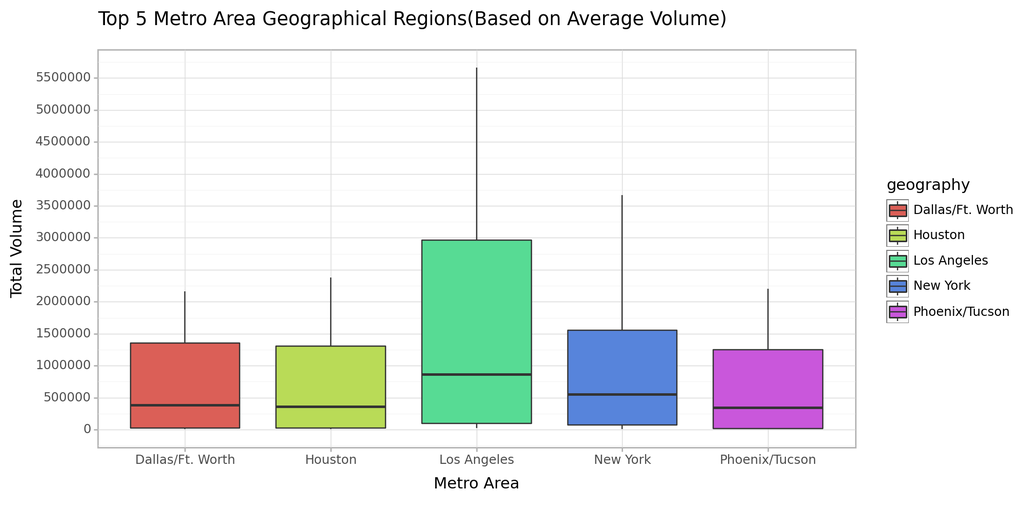

```
<Figure Size: (1000 x 500)>
```

```python
# Boxplot

plot = (
    ggplot(avocado_clean5, aes(x = 'geography', y = 'total_volume', fill = 'geography'))
    + geom_boxplot()
    + labs(title = "Top 5 Metro Area Geographical Regions(Based on Average Volume)", x="Metro Area", y="Total Volume")
    + scale_y_continuous(breaks = range(0, 6000000, 500000))
    + theme_light()
    + theme(figure_size = (10, 5))
)

plot
```

## 6. From your cleaned data set, create a data set with only these California regions and answer the following questions about these California regions only

```python
# New data set with only california regions.
avocado_cleanCA = avocado_clean[avocado_clean['geography'].isin(['Los Angeles', 'San Diego', 'Sacramento', 'San Francisco'])]
avocado_cleanCA
```

|  | date | average_price | total_volume | 4046 | 4225 | 4770 | total_bags | small_bags | large_bags | xlarge_bags | type | year | geography | geography type | month | day | year_column |
| --- | --- | --- | --- | --- | --- | --- | --- | --- | --- | --- | --- | --- | --- | --- | --- | --- | --- |
| 44 | 2015-01-04 | 0.85 | 2682159.95 | 1837999.65 | 524430.47 | 64225.78 | 255504.05 | 215571.80 | 36981.72 | 2950.53 | conventional | 2015 | Los Angeles | metro area | 1 | 4 | 2015 |
| 45 | 2015-01-04 | 1.25 | 54495.54 | 47721.51 | 1723.40 | 0.00 | 5050.63 | 5050.63 | 0.00 | 0.00 | organic | 2015 | Los Angeles | metro area | 1 | 4 | 2015 |
| 80 | 2015-01-04 | 1.05 | 430138.88 | 110693.69 | 270107.61 | 9737.50 | 39600.08 | 39600.08 | 0.00 | 0.00 | conventional | 2015 | Sacramento | metro area | 1 | 4 | 2015 |
| 81 | 2015-01-04 | 1.33 | 9213.49 | 3727.52 | 4327.52 | 0.00 | 1158.45 | 1158.45 | 0.00 | 0.00 | organic | 2015 | Sacramento | metro area | 1 | 4 | 2015 |
| 82 | 2015-01-04 | 0.94 | 461607.33 | 244152.26 | 165299.33 | 15302.75 | 36852.99 | 30884.29 | 5595.00 | 373.70 | conventional | 2015 | San Diego | metro area | 1 | 4 | 2015 |
| ... | ... | ... | ... | ... | ... | ... | ... | ... | ... | ... | ... | ... | ... | ... | ... | ... | ... |
| 33018 | 2020-11-29 | 1.43 | 23531.38 | 3303.69 | 2057.03 | 0.00 | 18170.66 | 18144.54 | 26.12 | 0.00 | organic | 2020 | Sacramento | metro area | 11 | 29 | 2020 |
| 33019 | 2020-11-29 | 1.12 | 469356.72 | 104509.99 | 19988.45 | 7210.47 | 337647.81 | 189341.36 | 127701.64 | 20604.81 | conventional | 2020 | San Diego | metro area | 11 | 29 | 2020 |
| 33020 | 2020-11-29 | 1.95 | 25799.95 | 894.63 | 838.11 | 0.00 | 24067.21 | 9691.46 | 14375.75 | 0.00 | organic | 2020 | San Diego | metro area | 11 | 29 | 2020 |
| 33021 | 2020-11-29 | 1.50 | 644141.37 | 128555.43 | 136718.24 | 5597.21 | 373270.49 | 159276.65 | 207760.32 | 6233.52 | conventional | 2020 | San Francisco | metro area | 11 | 29 | 2020 |
| 33022 | 2020-11-29 | 1.87 | 59527.02 | 2815.23 | 4542.30 | 0.00 | 52169.49 | 52034.33 | 135.16 | 0.00 | organic | 2020 | San Francisco | metro area | 11 | 29 | 2020 |

2448 rows × 17 columns

## 7. In which California regions is the price of organic versus conventional avocados most different? Support your answer with a few summary statistics AND a visualization.

```python
# Make new chart & column with the price difference between organic & conventional avocados.

avocado_cleanCA2 = avocado_cleanCA.groupby(['geography', 'type'])['average_price'].mean().unstack() #ChatGPT reccomended .unstack to make this chart

avocado_cleanCA2['price_difference'] = avocado_cleanCA2['organic'] - avocado_cleanCA2['conventional']

avocado_cleanCA2
```

| type geography | conventional | organic | price_difference |
| --- | --- | --- | --- |
| Los Angeles | 1.047124 | 1.574902 | 0.527778 |
| Sacramento | 1.295359 | 1.873856 | 0.578497 |
| San Diego | 1.113856 | 1.798366 | 0.684510 |
| San Francisco | 1.400490 | 2.119444 | 0.718954 |

The San Francisco region has the largest difference in price between conventional & organic avocados

[figure not shown]

```
<Figure Size: (1000 x 500)>
```

```python
# Visualization

plot = (
    ggplot(avocado_cleanCA, aes(x='geography', y='average_price', fill='type'))
    + geom_col(position='dodge') # Chat GPT assisted with dodge position to normalize chart
    + labs(title =" Average Prices of Organic vs Conventional Avocados by California Region", y = "Average Price ($)", x = "California Region")
    + theme_light()
    + theme(figure_size = (10,5))
)

plot
```

## 8. The following plot shows, for all four California regions, the proportion of the average Hass avocado sales that are small, large, or extra large; conventional vs. organic. Recreate the plot; you do not have to replicate the exact finishing touches - e.g., color, theme - but your plot should resemble the content of this plot.

```python
# Data filtered to California regions only
avocado_cleanCA
```

|  | date | average_price | total_volume | 4046 | 4225 | 4770 | total_bags | small_bags | large_bags | xlarge_bags | type | year | geography | geography type | month | day | year_column |
| --- | --- | --- | --- | --- | --- | --- | --- | --- | --- | --- | --- | --- | --- | --- | --- | --- | --- |
| 44 | 2015-01-04 | 0.85 | 2682159.95 | 1837999.65 | 524430.47 | 64225.78 | 255504.05 | 215571.80 | 36981.72 | 2950.53 | conventional | 2015 | Los Angeles | metro area | 1 | 4 | 2015 |
| 45 | 2015-01-04 | 1.25 | 54495.54 | 47721.51 | 1723.40 | 0.00 | 5050.63 | 5050.63 | 0.00 | 0.00 | organic | 2015 | Los Angeles | metro area | 1 | 4 | 2015 |
| 80 | 2015-01-04 | 1.05 | 430138.88 | 110693.69 | 270107.61 | 9737.50 | 39600.08 | 39600.08 | 0.00 | 0.00 | conventional | 2015 | Sacramento | metro area | 1 | 4 | 2015 |
| 81 | 2015-01-04 | 1.33 | 9213.49 | 3727.52 | 4327.52 | 0.00 | 1158.45 | 1158.45 | 0.00 | 0.00 | organic | 2015 | Sacramento | metro area | 1 | 4 | 2015 |
| 82 | 2015-01-04 | 0.94 | 461607.33 | 244152.26 | 165299.33 | 15302.75 | 36852.99 | 30884.29 | 5595.00 | 373.70 | conventional | 2015 | San Diego | metro area | 1 | 4 | 2015 |
| ... | ... | ... | ... | ... | ... | ... | ... | ... | ... | ... | ... | ... | ... | ... | ... | ... | ... |
| 33018 | 2020-11-29 | 1.43 | 23531.38 | 3303.69 | 2057.03 | 0.00 | 18170.66 | 18144.54 | 26.12 | 0.00 | organic | 2020 | Sacramento | metro area | 11 | 29 | 2020 |
| 33019 | 2020-11-29 | 1.12 | 469356.72 | 104509.99 | 19988.45 | 7210.47 | 337647.81 | 189341.36 | 127701.64 | 20604.81 | conventional | 2020 | San Diego | metro area | 11 | 29 | 2020 |
| 33020 | 2020-11-29 | 1.95 | 25799.95 | 894.63 | 838.11 | 0.00 | 24067.21 | 9691.46 | 14375.75 | 0.00 | organic | 2020 | San Diego | metro area | 11 | 29 | 2020 |
| 33021 | 2020-11-29 | 1.50 | 644141.37 | 128555.43 | 136718.24 | 5597.21 | 373270.49 | 159276.65 | 207760.32 | 6233.52 | conventional | 2020 | San Francisco | metro area | 11 | 29 | 2020 |
| 33022 | 2020-11-29 | 1.87 | 59527.02 | 2815.23 | 4542.30 | 0.00 | 52169.49 | 52034.33 | 135.16 | 0.00 | organic | 2020 | San Francisco | metro area | 11 | 29 | 2020 |

2448 rows × 17 columns

```python
transform_data = pd.melt(avocado_cleanCA, id_vars=['geography', 'type'],
                       value_vars=['4046', '4225', '4770'],
                       var_name='size', value_name='proportion')
```

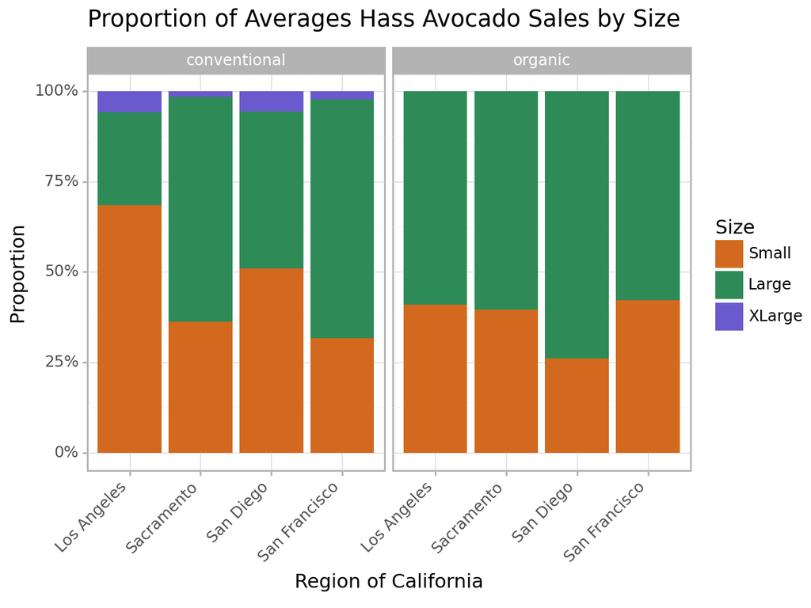

```
<Figure Size: (640 x 480)>
```

```python
plot = (ggplot(transform_data, aes(x='geography', y='proportion', fill='size'))
        + geom_bar(aes(fill='size', group='type'), position=position_fill(), stat='identity', width=0.9)
        + facet_wrap('~ type', ncol=2)
        + labs(title='Proportion of Averages Hass Avocado Sales by Size', x='Region of California', y='Proportion', fill='Size')
        + scale_y_continuous(breaks=(0, 0.25, 0.50, 0.75, 1), labels=lambda y: ['0%', '25%', '50%', '75%', '100%'])
        + scale_fill_manual(breaks=('4770', '4225', '4046'), values=('slateblue', 'seagreen', 'chocolate'), labels = {'4770': 'XLarge', '4225': 'Large', '4046': 'Small'})
        + theme_light()
        + theme(axis_text_x=element_text(rotation=45, hjust=1)) # Chat GPT assisted with spacing/rotating region names.

)

plot
```

# Using Outside Data

## A joke in the media is that Millennials can’t afford houses, because they spend all their money buying avocado toast. Let’s use this data set to address that claim.

```python
# Loading second data set
prices = pd.read_csv('/content/variable_full_hypothetical_california_house_prices.csv')
prices
```

|  | City | Date | Average House Price ($) |
| --- | --- | --- | --- |
| 0 | Los Angeles | 2015-01-04 | 636259 |
| 1 | Los Angeles | 2015-01-04 | 628258 |
| 2 | Sacramento | 2015-01-04 | 355547 |
| 3 | Sacramento | 2015-01-04 | 361692 |
| 4 | San Diego | 2015-01-04 | 571312 |
| ... | ... | ... | ... |
| 2443 | Sacramento | 2020-11-29 | 481299 |
| 2444 | San Diego | 2020-11-29 | 724141 |
| 2445 | San Diego | 2020-11-29 | 735355 |
| 2446 | San Francisco | 2020-11-29 | 984258 |
| 2447 | San Francisco | 2020-11-29 | 973913 |

2448 rows × 3 columns

```python
merged_data = pd.merge(avocado_cleanCA,
                       prices[['City', 'Date', 'Average House Price ($)']],
                       left_on=['geography', 'date'],
                       right_on=['City', 'Date'],
                       how='inner')

merged_data.drop(columns=['City', 'Date'], inplace=True)

merged_data
```

|  | date | average_price | total_volume | 4046 | 4225 | 4770 | total_bags | small_bags | large_bags | xlarge_bags | type | year | geography | geography type | month | day | year_column | Average House Price ($) |
| --- | --- | --- | --- | --- | --- | --- | --- | --- | --- | --- | --- | --- | --- | --- | --- | --- | --- | --- |
| 0 | 2015-01-04 | 0.85 | 2682159.95 | 1837999.65 | 524430.47 | 64225.78 | 255504.05 | 215571.80 | 36981.72 | 2950.53 | conventional | 2015 | Los Angeles | metro area | 1 | 4 | 2015 | 636259 |
| 1 | 2015-01-04 | 0.85 | 2682159.95 | 1837999.65 | 524430.47 | 64225.78 | 255504.05 | 215571.80 | 36981.72 | 2950.53 | conventional | 2015 | Los Angeles | metro area | 1 | 4 | 2015 | 628258 |
| 2 | 2015-01-04 | 1.25 | 54495.54 | 47721.51 | 1723.40 | 0.00 | 5050.63 | 5050.63 | 0.00 | 0.00 | organic | 2015 | Los Angeles | metro area | 1 | 4 | 2015 | 636259 |
| 3 | 2015-01-04 | 1.25 | 54495.54 | 47721.51 | 1723.40 | 0.00 | 5050.63 | 5050.63 | 0.00 | 0.00 | organic | 2015 | Los Angeles | metro area | 1 | 4 | 2015 | 628258 |
| 4 | 2015-01-04 | 1.05 | 430138.88 | 110693.69 | 270107.61 | 9737.50 | 39600.08 | 39600.08 | 0.00 | 0.00 | conventional | 2015 | Sacramento | metro area | 1 | 4 | 2015 | 355547 |
| ... | ... | ... | ... | ... | ... | ... | ... | ... | ... | ... | ... | ... | ... | ... | ... | ... | ... | ... |
| 4891 | 2020-11-29 | 1.95 | 25799.95 | 894.63 | 838.11 | 0.00 | 24067.21 | 9691.46 | 14375.75 | 0.00 | organic | 2020 | San Diego | metro area | 11 | 29 | 2020 | 735355 |
| 4892 | 2020-11-29 | 1.50 | 644141.37 | 128555.43 | 136718.24 | 5597.21 | 373270.49 | 159276.65 | 207760.32 | 6233.52 | conventional | 2020 | San Francisco | metro area | 11 | 29 | 2020 | 984258 |
| 4893 | 2020-11-29 | 1.50 | 644141.37 | 128555.43 | 136718.24 | 5597.21 | 373270.49 | 159276.65 | 207760.32 | 6233.52 | conventional | 2020 | San Francisco | metro area | 11 | 29 | 2020 | 973913 |
| 4894 | 2020-11-29 | 1.87 | 59527.02 | 2815.23 | 4542.30 | 0.00 | 52169.49 | 52034.33 | 135.16 | 0.00 | organic | 2020 | San Francisco | metro area | 11 | 29 | 2020 | 984258 |
| 4895 | 2020-11-29 | 1.87 | 59527.02 | 2815.23 | 4542.30 | 0.00 | 52169.49 | 52034.33 | 135.16 | 0.00 | organic | 2020 | San Francisco | metro area | 11 | 29 | 2020 | 973913 |

4896 rows × 18 columns

[figure not shown]

```
<Figure Size: (1000 x 500)>
```

```python
# Plot of House Prices vs. Avocado Volume
plot = (ggplot(merged_data, aes(x='total_volume', y='Average House Price ($)', color='geography'))
        + geom_point(alpha=0.6)
        + labs(title="House Prices vs. Avocado Volume", x="Total Volume of Avocados Purchased", y="Average House Price ($)")
        + theme_light()
        + scale_color_discrete(name="California Region")
        + theme(figure_size=(10, 5))
       )

plot
```

As seen above, there does not appear to be a relationship between the amount of avocados purchased, and the average house price in either region. Whether a region purhcases a lot or a little avocados, it does not appear to have a significant change or trend in the average house price within the region. The same appears to hold true for prices below.

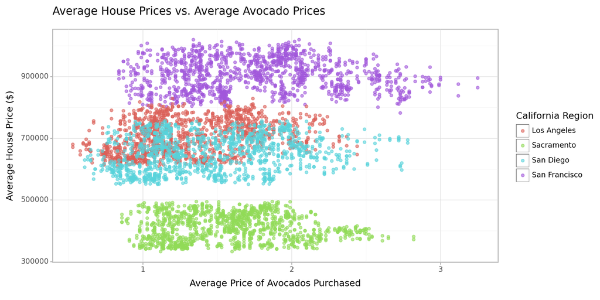

```
<Figure Size: (1000 x 500)>
```

```python
# Plot of House Prices vs. Avocado Prices
plot = (ggplot(merged_data, aes(x='average_price', y='Average House Price ($)', color='geography'))
        + geom_point(alpha=0.6)
        + labs(title="Average House Prices vs. Average Avocado Prices", x="Average Price of Avocados Purchased", y="Average House Price ($)")
        + theme_light()
        + scale_color_discrete(name="California Region")
        + theme(figure_size=(10, 5))
       )

plot
```